# Digging a bit into Airbnb Market in Seattle

In this notebook, we are to explore a little bit about airbnb market in Seattle. We will conduct some basic visualizations about:

1. Where the listings are?
2. How does the airbnb market grow in recent years?
3. How does the price vary accross different neighborhoods and property types?
4. What are the some of the popular wordings the hosts describe their property?
5. What are the some of the most popular amentities?

In the last part, we are to use basic NLP techniques to create a model to discover similar listings, and make recommendations accordingly.

Firstly, we import the necessary packages, and load the data into our working environment:

```python
import pandas as pd
import matplotlib.pyplot as plt
import numpy as np
import seaborn as sns
import re
from collections import defaultdict

from wordcloud import STOPWORDS, WordCloud

from sklearn.feature_extraction.text import TfidfVectorizer
from sklearn.metrics.pairwise import linear_kernel
```

```python
listings = pd.read_csv('seattle/listings_new.csv', dtype='object')
```

```python
print(f'Seattle listings has {listings.shape[0]} rows and {listings.shape[1]} columns.')
print(f'Seattle listings has {listings.id.nunique()} unique listings, owned by {listings.host_id.nunique()} hosts.')
```

```
Seattle listings has 8740 rows and 96 columns.
Seattle listings has 8740 unique listings, owned by 5441 hosts.
```

One of the first things we do is to find numbers of missing values in our dataset, and make decision about whether to keep or drop the column:

```python
def col_missing_perc(df, threshold = 0.5, drop=False):
    '''

    Show a df contains each column name and its corresponding missing percentage.
    If drop=True, return original df with column missing percentage higher than threshold dropped.

    Input:
        df: df you want to inspect or clean
        threshold: missing value percentage threshold
        drop: whether return a cleaned df
    Output:
        drop = False: show a df with column missing value percentage higher than threshold.
        drop = True: return a df with column missing percentage higher than threshold dropped.
    '''

    null_perc = (df.isnull().sum() / df.shape[0])
    null_perc = (null_perc[null_perc>threshold] * 100).sort_values(ascending=False)
    print(null_perc)


    if drop:
        new_df = df.drop(null_perc.index, axis=1)
        return new_df
```

```python
col_missing_perc(listings, threshold=0.4)
```

```
host_acceptance_rate    100.000000
xl_picture_url          100.000000
medium_url              100.000000
thumbnail_url           100.000000
license                  99.954233
square_feet              96.064073
monthly_price            89.084668
weekly_price             85.983982
notes                    42.505721
dtype: float64
```

From above, we can see that there aren't so many columns full of missing values. 4 columns are completely missing. We may need to look at raw data to try to find whether it is true, or it's something wrong with the data loading procress. But since those columns are not so relevant to what we are about to do in the following part, we choose to ignore those columns.

**Columns that we are interested in:**

1. price/cleaning_fee/security_deposit
2. number_of_reviews
3. review_scores_rating
4. neighbourhood_group_cleansed, property_type, room_type
5. amentities/accommodates/bathrooms/bedrooms/beds
6. latitude/longitude/is_location_exact
7. host_response_time/host_response_rate
8. host_is_superhost
9. name/summary/space/description/neighborhood_overview/transit

```python
def df_reduce(df, columns_keep):
    '''
    Return reduced df.

    Input:
        df: original df.
        columns_keep: a list of columns you want to keep
    Output:
        df with reduced column numbers.
    '''

    df = df.loc[:, columns_keep]
    return df
```

```python
columns_keep = ['id', #unique identifier
                'name', 'summary', 'space', 'description', 'neighborhood_overview', 'transit', 'latitude', 'longitude', 'is_location_exact', #about the listing
                'price', 'cleaning_fee', 'security_deposit', #dollar associated
                'neighbourhood_group_cleansed', 'property_type', 'room_type', #property associated
                'amenities', 'accommodates', 'bathrooms', 'bedrooms', 'beds', #amentities associated
                'review_scores_rating', 'first_review', 'number_of_reviews', #review score
                'host_response_time', 'host_response_rate', 'host_is_superhost'] #host associated
df = df_reduce(listings, columns_keep)
```

```python
df.head()
```

|  | id | name | summary | space | description | neighborhood_overview | transit | latitude | longitude | is_location_exact | ... | accommodates | bathrooms | bedrooms | beds | review_scores_rating | first_review | number_of_reviews | host_response_time | host_response_rate | host_is_superhost |
| --- | --- | --- | --- | --- | --- | --- | --- | --- | --- | --- | --- | --- | --- | --- | --- | --- | --- | --- | --- | --- | --- |
| 0 | 2318 | Casa Madrona - Urban Oasis, 1 block from the P... | Gorgeous, architect remodeled, 1917 Dutch Colo... | Casa Madrona is a gorgeous, architect remodele... | Gorgeous, architect remodeled, (Phone number h... | Madrona is a hidden gem of a neighborhood. It ... | NaN | 47.610819276291444 | -122.29081600224306 | t | ... | 8 | 2.5 | 4 | 4 | 100 | 2008-09-15 | 20 | within an hour | 100% | t |
| 1 | 4291 | Sunrise in Seattle Master Suite | This property is located in the lovely Maple L... | Located in Seattle, this is a spacious, clean ... | This property is located in the lovely Maple L... | NaN | NaN | 47.68780100864706 | -122.31342727386499 | t | ... | 2 | 1.0 | 1 | 1 | 91 | 2013-07-01 | 63 | within a few hours | 100% | f |
| 2 | 5682 | Cozy Studio, min. to downtown -WiFi | The Cozy Studio is a perfect launchpad for you... | Hello fellow travelers, Save some money and ha... | The Cozy Studio is a perfect launchpad for you... | NaN | Bus 120 is right outside and goes into downtow... | 47.52397950434662 | -122.35989059909596 | t | ... | 2 | 1.0 | 0 | 1 | 95 | 2010-03-21 | 461 | within an hour | 100% | t |
| 3 | 6606 | Fab, private seattle urban cottage! | NaN | Soo centrally located, this is a little house ... | Soo centrally located, this is a little house ... | A peaceful yet highly accessible neighborhood,... | NaN | 47.6541086069472 | -122.33760528816453 | t | ... | 2 | 1.0 | 1 | 1 | 93 | 2009-07-17 | 134 | within an hour | 100% | t |
| 4 | 9419 | Glorious sun room w/ memory foambed | This beautiful double room features a magical ... | Our new Sunny space has a private room from th... | This beautiful double room features a magical ... | Lots of restaurants (see our guide book) bars,... | Car 2 go is in this neigborhood Bus is across ... | 47.5506196980812 | -122.32013541411905 | t | ... | 2 | 3.0 | 1 | 1 | 92 | 2010-07-30 | 130 | within a few hours | 100% | t |

5 rows × 27 columns

After a deeper look at into our data, we may find that the dollar associated columns are not numeric type, which is not good for our analysis.

We need to remove the `$` sign and convert those columns into numeric type.

What's more, two columns, `is_location_exact` and `host_is_superhost`, are suppose to be in binary numeric type, and therefore, we will also convert "`t`" into 1, and "`f`" into 0.

We loaded all columns as object type, so that we should also convert all numeric variable into proper type.

```python
def remove_sign(s, sign):
    '''
    Remove dollar sign
    Input:
        s: a string you want to transfer
    Output:
        string with sign removed
    '''
    return re.sub(sign, '', str(s))

def change_dtype(df):
    '''
    Change dtypes of columns associated with dollars into float, and is_location_exact into boolean int,
    host_is_superhost into boolean int, host_response_rate into float
    Input:
        df: df you want to transfer.
    Output:
        return df with dtypes changed.
    '''
    d_columns = ['price', 'cleaning_fee', 'security_deposit', 'host_response_rate']
    df[d_columns] = df[d_columns].fillna('$0').applymap(lambda x:remove_sign(x,sign=r'[$%,]')).astype(float)
    df['amenities'] = df['amenities'].apply(remove_sign, sign=r'[{"}]')
    df['is_location_exact'] = df['is_location_exact'].map({'t':1, 'f':0})
    df['host_is_superhost'] = df['host_is_superhost'].map({'t':1, 'f':0})
    df[['id', 'latitude', 'longitude', 'accommodates', 'bathrooms', 'bedrooms', 'beds', 'review_scores_rating', 'number_of_reviews']] = \
    df[['id', 'latitude', 'longitude', 'accommodates', 'bathrooms', 'bedrooms', 'beds', 'review_scores_rating', 'number_of_reviews']].astype('float64')

    return df

df = change_dtype(df)
```

## 1. Where the listings are?

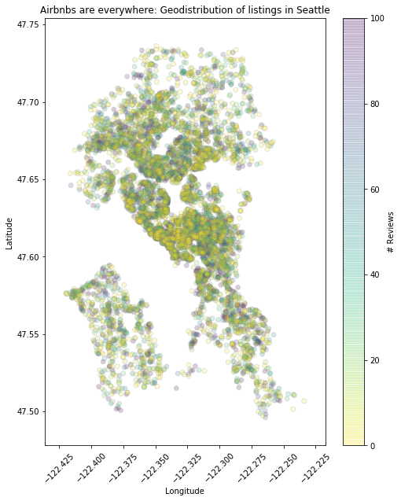

```python
plt.figure(figsize=(8,10))
fig = plt.scatter(data=df, x='longitude', y='latitude', alpha=0.2, c='number_of_reviews', cmap='viridis_r', vmin=0, vmax=100, edgecolors='gray')

cbar = plt.colorbar(fig)
cbar.set_label('# Reviews')
plt.xticks(rotation=45)
plt.xlabel('Longitude')
plt.ylabel('Latitude')
plt.title('Airbnbs are everywhere: Geodistribution of listings in Seattle');
```

**Conclusion:**

The graph above shows that Airbnbs are almost everywhere in Seattle. Most listings have review numbers between 0 to 40.

## What is the growth pattern of Airbnbs these years

```python
def get_listed_year(x):
    '''
    Return earlist date listed
    Input:
        x: first_review point
    Output:
        One point from list ['2012-01-01', '2013-01-01', '2014-01-01', '2015-01-01', '2016-01-01', '2017-01-01', '2018-01-01', '2019-01-01']
    '''
    date = ['2012-01-01', '2013-01-01', '2014-01-01', '2015-01-01', '2016-01-01', '2017-01-01', '2018-01-01', '2019-01-01']
    try:
        for d in date:
            if x <= d:
                return str(int(d[:4])-1)
    except:
        return np.nan
df['Year'] = df.first_review.apply(lambda x:get_listed_year(x))
```

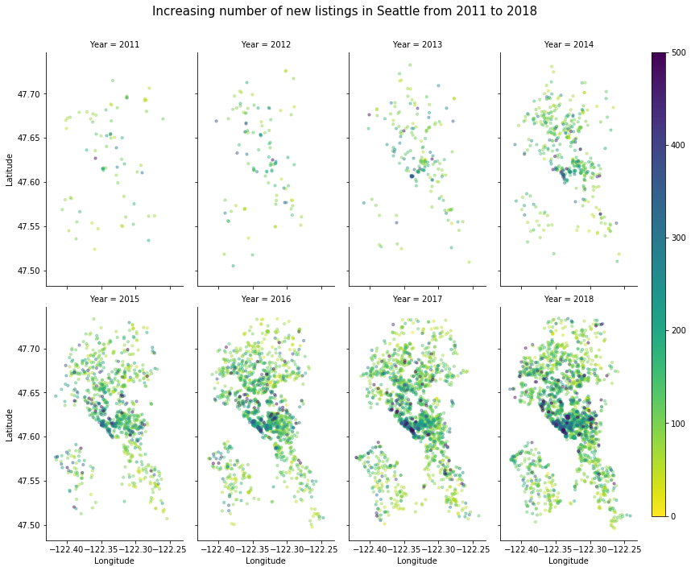

```python
g = sns.FacetGrid(data=df, col='Year', col_wrap=4, col_order=['2011','2012','2013','2014','2015','2016', '2017', '2018'], hue='price', palette='viridis_r', aspect=0.6, size=5)

def facet_scatter(x, y, c, **kwargs):
    kwargs.pop('color')
    plt.scatter(x, y, c=c, **kwargs)
vmin, vmax = 0, 500

g = g.map(facet_scatter, 'longitude', 'latitude', 'price', alpha=0.4, vmin=vmin, vmax=vmax, cmap='viridis_r', s=10)

g.fig.subplots_adjust(right=.92)
cax = g.fig.add_axes([.94, .1, .02, .8])
points = plt.scatter([], [], c=[], vmin=vmin, vmax=vmax, cmap='viridis_r')
g.fig.colorbar(points, cax=cax)
g.set_axis_labels('Longitude', 'Latitude')
g.fig.subplots_adjust(top=0.9)
g.fig.suptitle('Increasing number of new listings in Seattle from 2011 to 2018', fontsize=15);
```

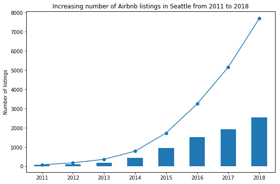

```python
seaPlot = df.Year.value_counts().sort_index().reset_index()
seaPlot['cumList'] = np.cumsum(seaPlot.Year)
seaPlot.columns = ['Year', 'numList', 'cumList']

ax = seaPlot[['Year','numList']].plot(kind='bar', legend=False, figsize=(9,6))
plt.xticks(rotation=0)
ax2 = ax.twinx()
ax2.plot(ax.get_xticks(),seaPlot['cumList'], marker='o')
ax.set_ylim(ax2.get_ylim())
ax2.set_yticks([])
ax2.set_title('Increasing number of Airbnb listings in Seattle from 2011 to 2018')
ax.set_xticklabels(['2011', '2012', '2013', '2014', '2015', '2016', '2017' ,'2018'])
ax.set_ylabel('Number of listings')
plt.show();
```

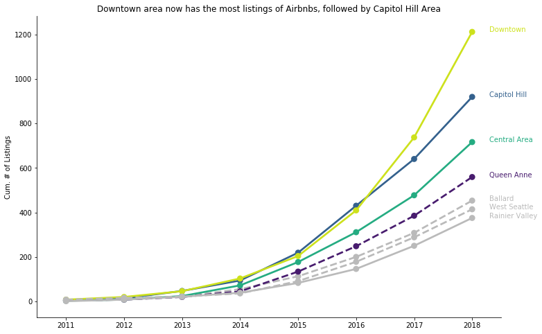

```python
# construct df used for plotting
neighborhoodPlot = df.groupby(['Year','neighbourhood_group_cleansed'])['id'].count().reset_index()
neighborhoodPlot.columns = ['Year', 'neighbourhood', 'counts']
neighborhoodPlot['cum_counts'] = neighborhoodPlot.groupby('neighbourhood').cumsum()
nbh_list = neighborhoodPlot[neighborhoodPlot.Year == '2018'].sort_values(by='cum_counts', ascending=False).neighbourhood[1:8].tolist()
neighborhoodPlot = neighborhoodPlot.query('neighbourhood in @nbh_list')

# set color palette and linestyles
cp = sns.color_palette('viridis_r', n_colors=12)
gray = sns.color_palette('gray', n_colors=10)[-3]
palette = {'Downtown':cp[0], 'Capitol Hill':cp[8], 'Queen Anne':cp[11], 'Central Area':cp[4], 'Rainier Valley': gray, 'West Seattle':gray, 'Ballard':gray}
linestyles = ['--', '-','-','-','--','-','--']

# plot
fig = plt.figure(figsize=(12,8))
ax = sns.pointplot(data=neighborhoodPlot, x='Year', y='cum_counts', hue='neighbourhood', palette=palette, linestyles=linestyles)
ax.legend_.remove()

# add customized legends
textDf = neighborhoodPlot[neighborhoodPlot.Year=='2018'].reset_index(drop=True).sort_values(by='cum_counts', ascending=False)
for i in range(textDf.shape[0]):
    neighborhood = textDf.loc[i,'neighbourhood']
    plt.text(x=7.3, y=textDf.loc[i, 'cum_counts'], s=neighborhood, color=palette[neighborhood])

ax.set_xlabel('')
ax.set_ylabel('Cum. # of Listings')
ax.set_title('Downtown area now has the most listings of Airbnbs, followed by Capitol Hill Area')
sns.despine(ax=ax);
```

**Conclusion:**

We can see, the Airbnb market growth in terms of numbers listed was exponential from 2011 to 2018 in Seattle, a very strong signal of the raising sharing economy. Downtown region has the most number of listings, followed by Capitol Hill and Central Area.

## How does price vary across different neighborhoods and property types

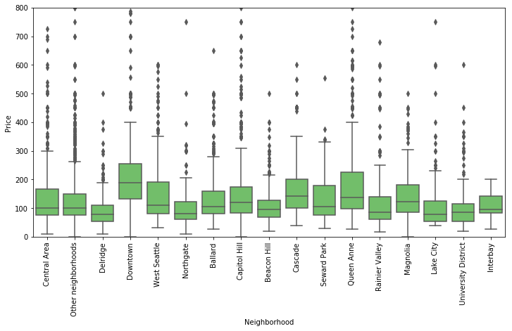

```python
plt.figure(figsize = (12, 6))
sns.boxplot(x = 'neighbourhood_group_cleansed', y = 'price',  data = df, color=sns.color_palette('viridis_r', n_colors=12)[2])
xt = plt.xticks(rotation=90)
plt.ylim((0, 800))
plt.xlabel('Neighborhood')
plt.ylabel('Price');
```

The box plot shows that prices vary a lot across different neighborhoods, and the skewness is reletively high. Therefore, we decide to plot a heatmap on median listing price across neighborhood against property type.

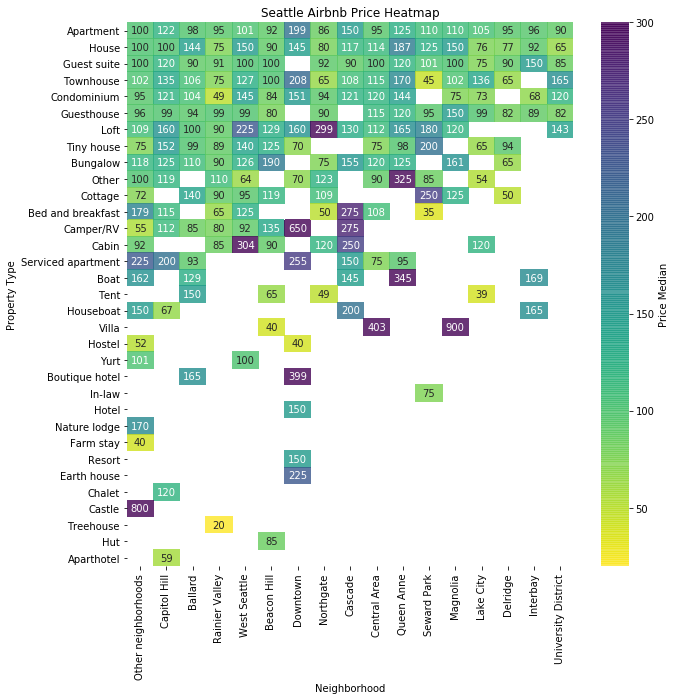

```python
neighbor_property = df.groupby(['property_type', 'neighbourhood_group_cleansed']).price.median().unstack()
col_order = neighbor_property.isnull().sum().sort_values().index
ind_order = neighbor_property.isnull().sum(axis=1).sort_values().index
neighbor_property = neighbor_property.loc[ind_order, col_order]

fig = plt.figure(figsize=(10,10))
sns.heatmap(neighbor_property, annot=True, fmt='.0f', cmap='viridis_r', alpha=0.8, cbar_kws={'label':'Price Median'}, vmax=300)
plt.xlabel('Neighborhood')
plt.ylabel('Property Type')
plt.title('Seattle Airbnb Price Heatmap');
```

**Conclusion:**

## What are the frequently used words in describing an Airbnb

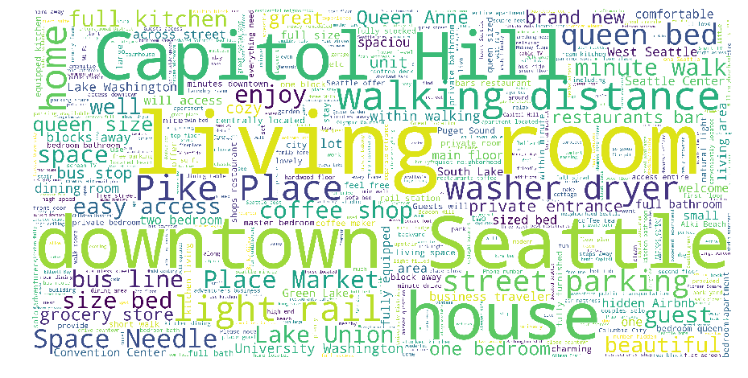

```python
description_corpus = ' '.join(df.description.dropna())

description_wc = WordCloud(stopwords=STOPWORDS, background_color='white', max_words=500, height=2000, width=4000).generate(description_corpus)
plt.figure(figsize = (16,8))
plt.imshow(description_wc)
plt.axis('off')
plt.show()
```

## What are the must have amenities in Seattle

```python
def get_all_amenities(df):
    '''
    Return all amenities contained in df_list with counts
    Input:
        df_list: the amenities df column
    Output:
        return a df with amenity name, its count and % within total number of listing available categorized by year
    '''
    amenity_dict = defaultdict(lambda:defaultdict(int))
    for l in range(df.shape[0]):
        year = df.Year[l]
        if year is np.nan:
            continue
        for a in df.amenities[l].split(','):
            if a != '':
                amenity_dict[year][a]+=1
    numListing = df.Year.value_counts().sort_index().cumsum().reset_index()
    numListing.columns = ['Year', 'numListings']
    amenity = pd.DataFrame.from_dict(amenity_dict, orient='index').reset_index().melt(var_name='amenity', value_name='counts', id_vars='index')
    amenity.columns = ['Year', 'amenity', 'amount']
    amenity['amountCumSum'] = amenity.groupby(['amenity']).cumsum()
    amenity = pd.merge(amenity, numListing, on='Year')
    amenity = amenity.assign(percentage = amenity.amountCumSum / amenity.numListings * 100)

    return amenity
amenities = get_all_amenities(df)
```

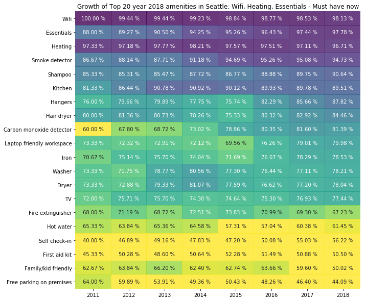

```python
amenity_list = amenities[amenities.Year == '2018'].sort_values(by='percentage', ascending=False).amenity.tolist()[:20]
amenityPlot = amenities.query('amenity in @amenity_list')
amenityPlot = amenityPlot.groupby(['amenity', 'Year']).percentage.mean().unstack()
amenityPlot = amenityPlot.sort_values(by='2018', ascending=False)

fig = plt.figure(figsize=(10,10))
ax = sns.heatmap(amenityPlot, cmap='viridis_r', vmin=60, vmax=100, annot=True, fmt='.2f', cbar=False, alpha=0.8)
for t in ax.texts:
    t.set_text(t.get_text() + " %")
ax.set_xlabel('')
ax.set_ylabel('')
ax.set_title('Growth of Top 20 year 2018 amenities in Seattle: Wifi, Heating, Essentials - Must have now');
```

**Conclusion:**

It pretty interesting to look at this heatmap. It shows the percentage of Airbnbs having a particular amenity. The amenities choosen are top 20 amenities that Airbnb have in year 2018. We can see that Wifi is definitely the most important thing. For a place like Seattle, heating is one of the must haves. We can also observe the raising number of carbon monoxide detector equipped in an Airbnb. Interestingly, free parking on premises is declining, maybe because of the high price to park your car!

## Finding similar listing according to description

Next, we are going to do a little bit of easy machine learning. We try to create a TF-IDF matrix of both unigrams and bigrams for every listings we have. The “stop words” parameter tells the TF-IDF module to ignore common English words like 'the', ‘about’, etc. TF-IDF will parse through the descriptions, identify distinct phrases in each item's description, and then find similar contents based on those phrases.

**TF:** Term Frequency, which measures how frequently a term occurs in a document. Since every document is different in length, it is possible that a term would appear much more times in long documents than shorter ones. Thus, the term frequency is often divided by the document length (aka. the total number of terms in the document) as a way of normalization:

TF(t) = (Number of times term t appears in a document) / (Total number of terms in the document).

**IDF:** Inverse Document Frequency, which measures how important a term is. While computing TF, all terms are considered equally important. However it is known that certain terms, such as "is", "of", and "that", may appear a lot of times but have little importance. Thus we need to weigh down the frequent terms while scale up the rare ones, by computing the following:

IDF(t) = log_e(Total number of documents / Number of documents with term t in it).

```python
df['content'] = df[['name', 'description']].astype(str).apply(lambda x: ' // '.join(x), axis = 1)
df['content'].fillna('Null', inplace = True)
tfidf = TfidfVectorizer(analyzer = 'word', ngram_range = (1, 2), min_df = 0, stop_words = 'english')
tfidf_matrix = tfidf.fit_transform(df['content'])
```

We use cosine distance to represent the similarity of two descriptions. This is basically saying that the smaller the angle between two vectors, the more similar the two vectors are.

```python
cosine_similarities = linear_kernel(tfidf_matrix, tfidf_matrix)
```

After calculating the cosine similarites, we can get our results. We iterate through each item's similar items and store the 100 most-similar!

```python
results = {}
for idx, row in df.iterrows():
    similar_indices = cosine_similarities[idx].argsort()[:-100:-1]
    similar_items = [(cosine_similarities[idx][i], df['id'][i]) for i in similar_indices]
    results[row['id']] = similar_items[1:]
```

```python
def item(id_, df=df):
    '''
    Return the listing name and description
    Input:
        id_: listing id
        df: listing df
    Output:
        a string containing listing name and its description
    '''
    name   = df.loc[df['id'] == id_]['content'].tolist()[0].split(' // ')[0]
    desc   = ' \nDescription: ' + df.loc[df['id'] == id_]['content'].tolist()[0].split(' // ')[1][0:330] + '...'
    prediction = name + desc
    return prediction

def recommend(item_id, n, results=results, df=df):
    '''
    Return n recommendations
    Input:
        item_id: listing id
        n: number of recommendations
        results: similarity score results
        df: listing df
    Output:
        print n recommendations (name and description)
    '''
    print('Recommending ' + str(n) + ' listings similar to ' + item(item_id, df))
    print('---')
    recs = results[item_id][:n]
    for rec in recs:
        print('\nRecommended: ' + item(rec[1]) + '\n(similarity score:' + str(rec[0]) + ')')
```

```python
recommend(item_id = 19619, n = 5)
```

```
Recommending 5 listings similar to Lively Vacation Home in Seattle with Puget Sound Views
Description: Take in scenic views from the bedroom balcony as coffee brews in the kitchen or watch a show in the bright open-plan living room with bay windows and cool accents. Later, go to the pool for a swim or behold Puget Sound views from the roof terrace....
---

Recommended: @Pike Place
Description: One bedroom apartment close to Pike Place. Great views over Puget Sound. Modern building.  Well equipped kitchen. Queen bed and sofa bed. WIFI. Gym in the building. Roof terrace with BBQ...
(similarity score:0.11722243827993975)

Recommended: Stylish, dog-friendly condo at Arthouse w/ private balcony & Puget Sound views!
Description: This property is a 461  square feet,  1 Bedroom, 1 bathroom accommodation located in Seattle.  Stylish, dog-friendly condo with a private balcony & Puget Sound views! offers 1 Sofa bed, 1 Queen bed. It can host 4 people.  This accommodation features washer/dryer. Please see the descript…
(similarity score:0.10281141529564444)

Recommended: Apartment with Balcony and Shared Pool Included
Description: Start your day out on the bedroom balcony and enjoy lush views of Seattle's downtown as you plan out your day. This relaxed, open-plan space has pared-back furnishings and offers access to a shared BBQ terrace and pool, as well as a fitness center....
(similarity score:0.09437879912608939)

Recommended: Lower Queen Anne Apartment with Views of Puget Sound
Description: You’ll love my place because of its central location, ambiance and conveniences. Enjoy 24HR access to a rooftop deck equipped with BBQ grill, sitting areas and the best views of the Space Needle and Puget Sound.  Private gated parking garage....
(similarity score:0.08791519434567086)

Recommended: Ballard, Seattle Fantastic Puget Sound View Home
Description: Slide open the balcony doors for panoramic views across Puget Sound, or relax in the hot tub at sunset. Prepare meals in a full kitchen with a gas stove and family size appliances. Curl up in front of the fireplace at the end of the day....
(similarity score:0.08751829511143538)
```

**Conclusion:**

Using the technique above, we can make simple recommendations to users whose ideal airbnb was booked to find another perfectly matched listing. Currently, we have no idea about how accurate this recommender model works. We can further incorporate more features (i.e. geographical data, price, review scores, etc.) to make our recommendation more sophisticated. We can also try to predict ratings for a listing, and thus having a way to evaluate our model using a tangible metric.